# Text prediction algorithm

Adrian Fabela  
15/04/2021

Introduction

This project has the aim of deploying an algorithm with which a user can start typing a sentence and get suggested follow-up words. This type of applications are widely used today due to the performance power of computers and the user's will for more comfort.

Strategy for N-gram building

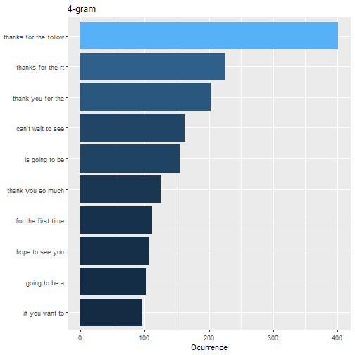

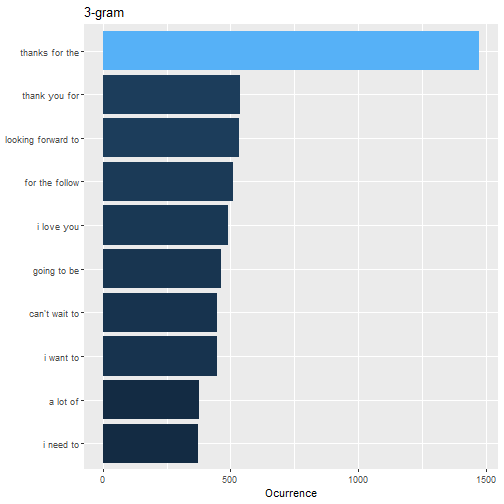

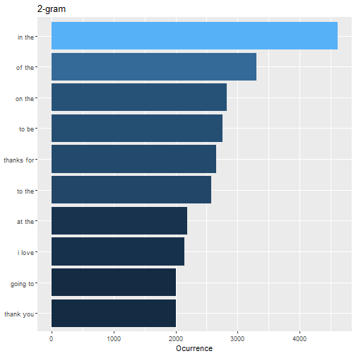

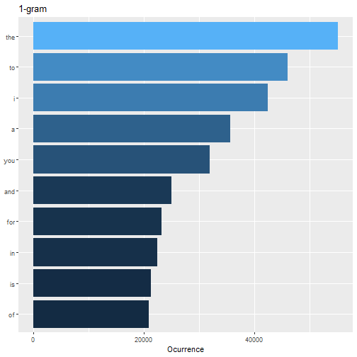

Algorithm logic

The logic behind the algorithm was to use the 4-gram, 3-gram, 2-gram and 1-gram tables and go through them with a filter function from dyplr as what is the input from the user. The shniy app then runs a reactive variable which makes sure that everytime the input from the user is changed it does the same for each word looking firstly on the 4-gram then jump in to the 3-gram and so forth decreasing the level of the n-gram.

Results

As it can be seen in the application, the response time is outstandingly fast. It can even be compared to that you see in your phone. With higher computational power it can be stated that the number of N-grams which could be used as reference sets can go beyond 20 and thus have enough information to even build whole sentences based on either tweets, news or blogs.

Conclusion

The power such applications can provide with regards to text mining is limited to the programmers creativity and the power of his super computer.